# 第9章 新製品の普及

更新：2026-05-13

## データ

#### Bass.txt

```r
# Bass <- read.table("dataset/Bass.txt", header = T, sep = ",")
Bass <- read.csv("dataset/Bass.txt")
```

|  | 時点 | 購買者数 | 累積購買者数 | 一期前累積購買者数 | 一期前累積購買者数の二乗 |
| --- | --- | --- | --- | --- | --- |
| 1 | 1 | 4998 | 4998 | 0 | 0 |
| 2 | 2 | 5398 | 10396 | 4998 | 24980004 |
| 3 | 3 | 5611 | 16007 | 10396 | 108076816 |
| 4 | 4 | 5574 | 21581 | 16007 | 256224049 |
| 5 | 5 | 5292 | 26873 | 21581 | 465739561 |
| 6 | 6 | 4798 | 31671 | 26873 | 722158129 |

## 6.1 回帰分析

```r
result <- lm(購買者数 ~ 一期前累積購買者数 + 一期前累積購買者数の二乗, data = Bass)
summary(result)
```

```
##
## Call:
## lm(formula = 購買者数 ~ 一期前累積購買者数 + 一期前累積購買者数の二乗,
##     data = Bass)
##
## Residuals:
##     Min      1Q  Median      3Q     Max
## -4.9350 -1.0635 -0.4254  2.2470  4.8220
##
## Coefficients:
##                            Estimate Std. Error t value Pr(>|t|)
## (Intercept)               4.999e+03  2.249e+00  2222.8   <2e-16 ***
## 一期前累積購買者数        9.994e-02  2.042e-04   489.5   <2e-16 ***
## 一期前累積購買者数の二乗 -3.997e-06  3.807e-09 -1049.8   <2e-16 ***
## ---
## Signif. codes:  0 '***' 0.001 '**' 0.01 '*' 0.05 '.' 0.1 ' ' 1
##
## Residual standard error: 2.947 on 12 degrees of freedom
## Multiple R-squared:      1,  Adjusted R-squared:      1
## F-statistic: 3.156e+06 on 2 and 12 DF,  p-value: < 2.2e-16
```

`4.999e+03`は $4.999 \times 10^3 = 4999$，`9.994e-02`は $9.994 \times 10^{-2} = 0.09994$ を意味する

#### m, p, qの計算

```r
a <- result$coefficients[1]
b <- result$coefficients[2]
c <- result$coefficients[3]
m <- (-b-sqrt(b^2-4*a*c))/(2*c)
p <- a/m
q <- p+b

print(c(m, p, q))
```

```
## 一期前累積購買者数        (Intercept)        (Intercept)
##       5.001236e+04       9.995869e-02       1.999003e-01
```

#### 購買者数と予測値の推移

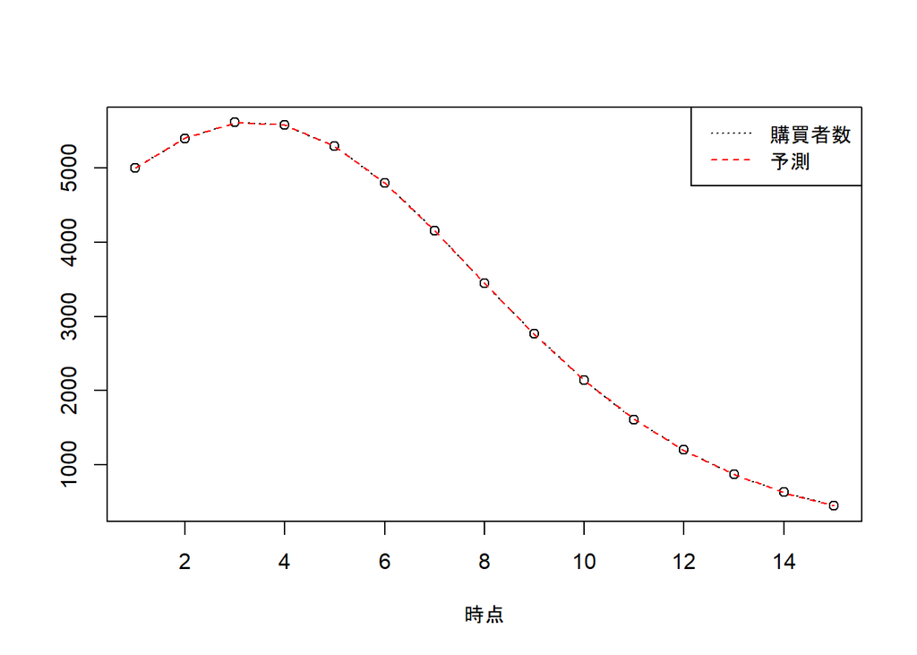

```r
# 図9.12
cols <- c("black", "red")  # 折れ線グラフの色
ltys <- c(3, 2)    # 折れ線グラフの線のタイプ
plot(x = Bass$時点, y = Bass$購買者数, type = "b", col = cols[1], lty = ltys[1],
     xlab = "時点", ylab = "")
lines(x = Bass$時点, y = result$fitted.values, col = cols[2], lty = ltys[2])
legend("topright", legend = c("購買者数", "予測"), col = cols, lty = ltys)
```

教科書では図9.12を描くのに予測値を新しい変数として作成してデータセットに追加しているが，`lm` 関数の出力に予測値 `fitted.values` が含まれているため，それを利用した

## 参考：非線形最小二乗法

教科書の式(9.4)の回帰分析（`lm` 関数）を使ったバスモデルの推定はコンピュータの性能が低い時代の方法で，現代ではm，p，qは非線形最小二乗法（`nls` 関数）で，教科書の式(9.1)から直接推定した方が早い。

非線形最小二乗法では，パラメータ（m，p，q）に適当な初期値を与えて，バスモデルの左辺 $n_t$ と右辺 $p(m-N_{t-1}) + q \frac{N_{t-1}}{m} (m-N_{t-1})$ の残差二乗和（＝左辺と右辺の差の二乗の合計値）

$$\sum_{t=1}^T \left( n_t - p(m-N_{t-1}) -
q \frac{N_{t-1}}{m} (m-N_{t-1})\right)^2$$

を計算し，その残差二乗和が小さくなるようにパラメータを更新していき，残差二乗和が最小となるm，p，qの値を見つけて推定値とする。

初期値のうち潜在市場規模mの設定によっては，うまくパラメータが推定できない場合があるので，エラーが出る場合はmの初期値を変更してみること。

```r
# データの列名の変更
colnames(Bass) <- c("time", "n", "Nt", "Nt1", "Nt1s")

# パラメータ推定
result <- nls(
  n ~ p * (m - Nt1) + q * Nt1/m * (m - Nt1),  # 式(9.1)
  data = Bass, # データ
  start = list(p = 0.1, q = 0.1, m = 5000))  # パラメータの初期値
summary(result)
```

```
##
## Formula: n ~ p * (m - Nt1) + q * Nt1/m * (m - Nt1)
##
## Parameters:
##    Estimate Std. Error t value Pr(>|t|)
## p 9.996e-02  4.343e-05    2301   <2e-16 ***
## q 1.999e-01  1.762e-04    1135   <2e-16 ***
## m 5.001e+04  5.450e+00    9176   <2e-16 ***
## ---
## Signif. codes:  0 '***' 0.001 '**' 0.01 '*' 0.05 '.' 0.1 ' ' 1
##
## Residual standard error: 2.947 on 12 degrees of freedom
##
## Number of iterations to convergence: 6
## Achieved convergence tolerance: 6.134e-07
```

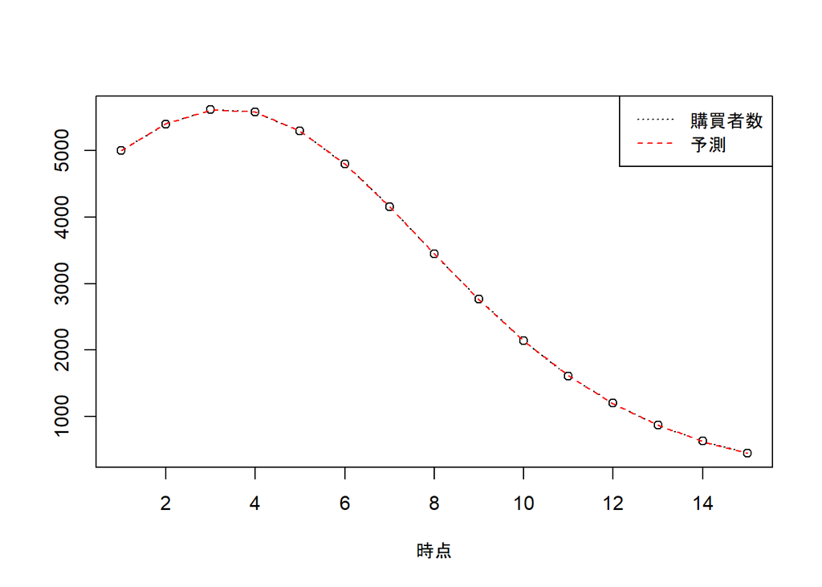

```r
# 購買者数の予測値の計算とデータへの追加
Bass$prediction <- predict(result)

# 予測値プロット
cols <- c("black", "red")  # 折れ線グラフの色
ltys <- c(3, 2)    # 折れ線グラフの線のタイプ
plot(x = Bass$time, y = Bass$n, type = "b", col = cols[1], lty = ltys[1],
     xlab = "時点", ylab = "")
lines(x = Bass$time, y = Bass$prediction, col = cols[2], lty = ltys[2])
legend("topright", legend = c("購買者数", "予測"), col = cols, lty = ltys)
```